# Analyzing the first 2020 presidential debate

A text mining approach by @bonschorno

**Repository**: presidentialdebate2020 | **Contact**: I’m on [Twitter](https://twitter.com/bonschorno) or you can find my e-mail on the Github page.

## Intro

I must admit I did not watch the debate between the two presidential candidates. But it seems that I didn’t miss anything either. All major American newspapers concluded that the discussion rapidly turned into chaos. The Times in London disappointedly concluded: “The clearest loser of this first presidential debate between Donald Trump and Joe Biden was America” (Source: [The Times](https://www.thetimes.co.uk/article/us-presidential-debate-donald-trump-launches-tirade-of-personal-attacks-on-joe-biden-in-chaotic-debate-jfmwxjmqj)).

So, after CNN’s Dana Bash calling the debate a “shitshow” (Source: [CNN](https://www.realclearpolitics.com/video/2020/09/29/cnns_dana_bash_debate_was_a_shitshow.html)), I wanted to analyze it myself and checked out the [USA Today](https://eu.usatoday.com/story/news/politics/elections/2020/09/30/presidential-debate-read-full-transcript-first-debate/3587462001/) page that published the meticulously transcribed debate a few days ago. I scraped the website using the `rvest` package; for the data wrangling and visualizations, I used the different packages from the `tidyverse.` More advanced visualizations like the “keyness”-plot were created using the `quanteda` package.

Some caveats at the beginning. For simplicity’s sake, some issues are not flawlessly coded. For example, a statement by presidential candidate Biden is not included because it was awkwardly embedded in the HTML document and its exclusion greatly simplified the code. Also, for the descriptive plots at the beginning, I counted the number of words only in a crude way and did not remove the stopwords. I do not assume that this has a strong influence on the visualization. If it does, please file an issue. You can find the complete code in the following repo.

## Who, how much and when?

The first visualizations follow very simple questions: Who has made how many statements? How long were these statements? And did the length of the statements change during the debate?

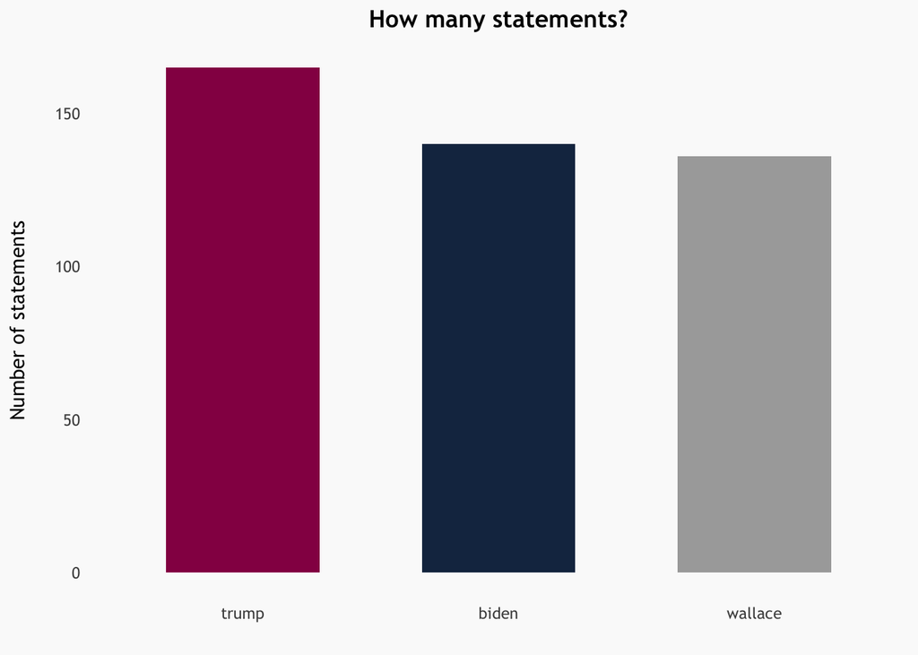

With 165 statements, Trump had the most and 25 more statements than candidate Biden. However, this number doesn’t allow any conclusions about the length of their comments, which is probably more meaningful. It should be pointed out how often Chris Wallace, the moderator, spoke. This probably has its good reasons, but more about this later.

First, the question arises whether Trump’s statements were not only more frequent but also longer. A density plot helps us to examine the comments of the two candidates in more detail.

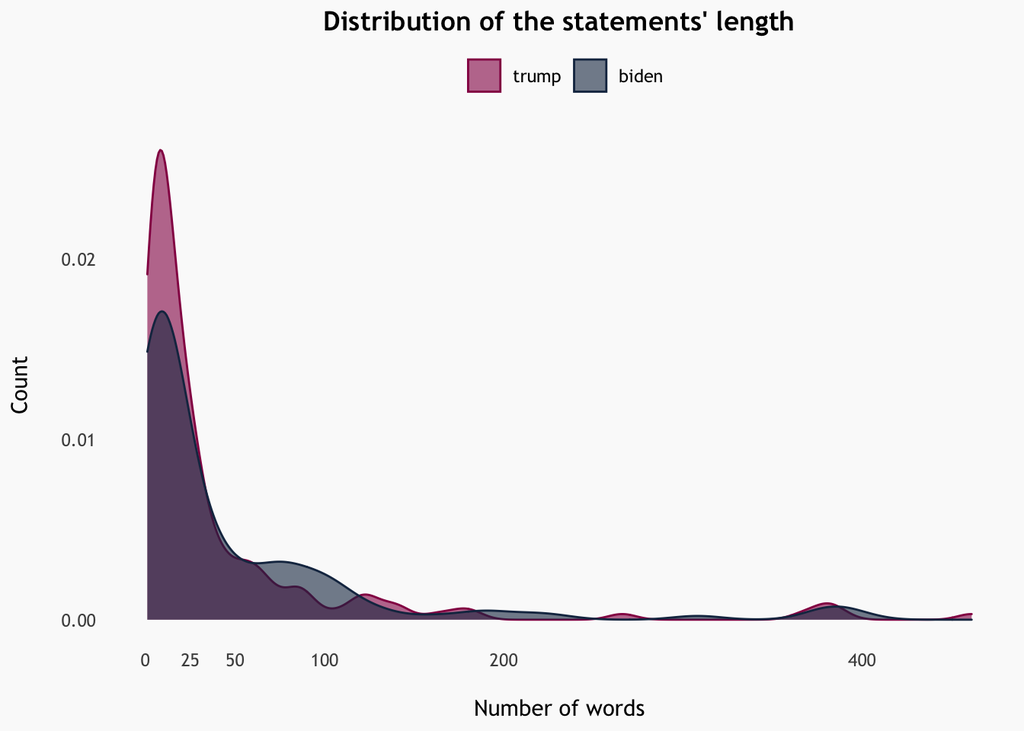

Two aspects become apparent. First, both candidates have only a few statements longer than 100 words. Most comments are concentrated around a length of 10-25 words. For comparison, although difficult to define, an average sentence in literature contains between 15-20 words. Sentence length is obviously much shorter in spoken language. It varies from medium to medium, from conversation to conversation, but these figures show that most of the candidates’ statements consisted of perhaps two, at most three sentences. A first indication of how the debate did not consist of longer phrases, but rather of short, interrupted statements.

Finally, the question arises whether the length of the statements had changed throughout the debate. For instance, did the statements become shorter the longer the debate lasted? How did the candidates react to remarks from the other person? The following plot provides information on this.

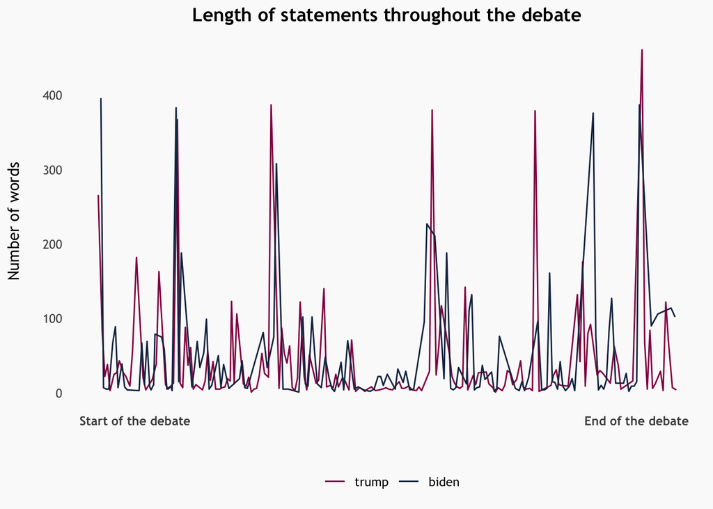

It is easy to read the graphic’s spikes, reflecting the two candidates’ very long statements now and then. Most of the time, they follow each other directly. Either Trump reacted immediately with a long comment to a lengthy statement from Biden or vice versa.

To summarize these first descriptive graphics: Trump placed more statements than Biden, but many were shorter than those of the former vice president. The last graph showed that the length of the statements followed a clear pattern throughout the debate. One candidate responded with a lengthy commentary to a detailed statement by the other or vice versa. This pattern runs through the entire debate, and the length of the words hardly changed during the discussion.

We already know a little about how the two candidates presented themselves, but it is still unclear WHAT they said at all. To a certain extent, the content of the statements was predetermined by the various thematic segments, but this still leaves a great deal of room for deciphering the two opponents’ personalities more precisely based on their statements.

Accordingly, the following section attempts to illuminate the substantive level of the debate. For this purpose, I first plot the crude statistics of the most frequently used words, before more advanced methods such as “textual keyness” reveal which words have been used in a person-specific way. Finally, networks show the co-occurrences of the words in the statements of the two candidates.

## What exactly?

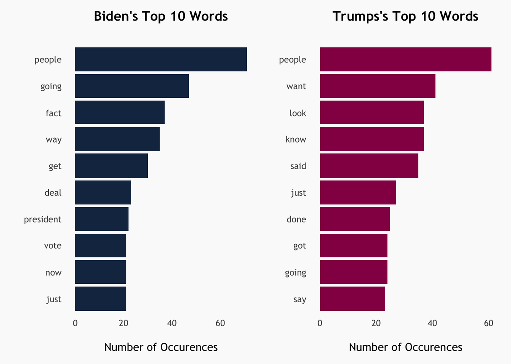

The president’s most frequently used words, on the other hand, allow little inference without context. The words “want”, “look”, “know”, “said”, but also the other words can be used in very different contexts, making interpretations at this point premature.

Let’s go one step further and look at a so-called “keyness” plot. In very simplified terms, “keyness” in this case means how candidate-specific a particular word is. The higher the absolute value of Chi-Square, the more candidate-specific the word is. Some interesting tendencies can already be observed here.

The most Trump specific word is “joe”. This is not surprising. Those who watched the debate will remember how often the president addressed his opponent by his first name. Although not depicted, “chris”, i.e. the moderator’s name, appears among the “most typical” Trump words. Trump’s direct manner is thus clearly visible or audible in this debate as well. It is also noticeable that the word “country” is almost only used in conjunction with Trump’s statements. Accordingly, it is listed in the second place of the “keyness” plot. If you take a closer look at the phrases, you can see that the word “years” is ambiguous in Trump’s statements.

On the one hand, he uses it to show how much he has done in the four years (another Trump-specific word). On the other hand, he uses it to deliver how Biden failed. Several times Trump mentioned how Biden had achieved nothing in those many years.

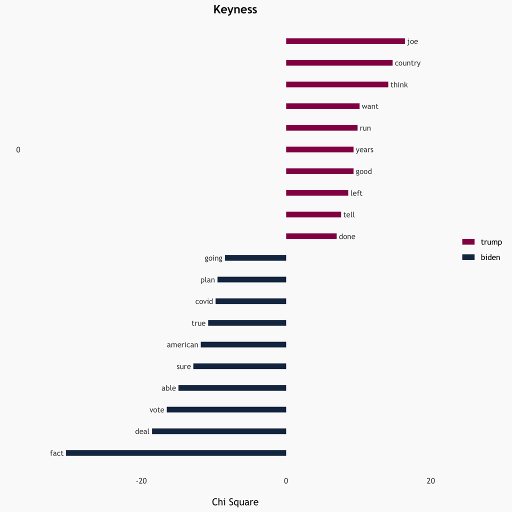

And what about Biden? As in the plot above, the word “fact” immediately catches the eye. Biden used this word 37 times, Trump, not a single time. Accordingly, it is the first of the Biden-specific words. In second place appears “deal”.

On the one hand, Biden means the green new deal, which he refers to several times. On the other hand, he often used the phrase “here’s the deal” in the debate, causing this word to be associated with Biden. Other terms frequently used by candidate Biden are “american”, “covid” or “true”.

So far, we have only looked at individual words. However, it is often more informative to look at the words embedded in a context. Take the word “true”, which was often used by Biden. He might have meant true facts (true) as well as false facts (not true). We only know this when we look at the words before or after the relevant word, respectively. Such word pairs or three words together are called bi-grams or tri-grams. While these n-grams can easily be extracted using certain functions, they are difficult to visualize informatively. For this reason, I decided to use an alternative.

Network plots follow a similar, albeit slightly different approach. Here we mainly deal with the co-occurrence of two words. For example, President Trump often used the word “country”. But in connection with which other words did he use it? The following plots provide information on this. The 50 most frequent words of both candidates were selected. More intense colors represent a more frequent co-occurrence of two words. As the minimum proportion for co-occurrence frequencies of features to be included, I chose 0.75.

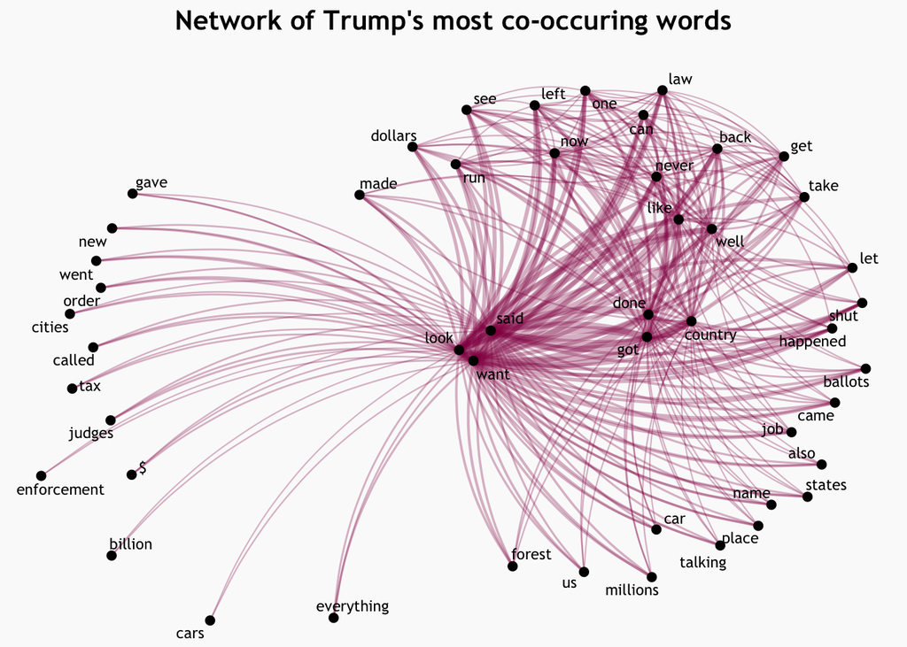

In the center of the network, we see the most frequently used words (“want”, “look”, “said”) while the less often used words are shown at the border. Although it is difficult to make sense of the many different connections, some supposedly random words stand out. “Forest” for example. In one of his statements about wildfires, Trump mentioned the word several times, but never again after that. Another such example is “cars”. Can we better decipher the co-occurring words of Biden?

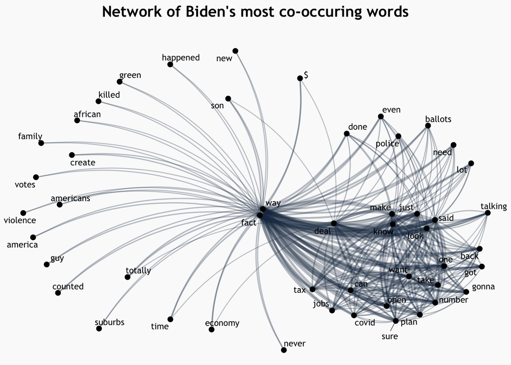

Again, the more intense colored lines represent the co-occurrences between frequent words. “Way”, “fact” or “deal” are at the center. “Deal”, for example, co-occurs with very different terms such as “ballots”, “time”, “economy” or " tax“, which may indicate a wide-ranging demand for reform on the part of Biden. At the same time, however, we have to remember that Biden used the expression”here’s the deal" very often, and thus certain relations between the words might be distorted.

While these network plots are not easy to decipher, they allow more detailed insight into the connections between the different words and, thus, at best, the two presidential candidates’ statements. However, to draw more precise conclusions, several further steps would have to be taken. This brings me to the last section of this article.

## What’s next?

This contribution represents only a tiny part of the multitude of possibilities offered by text data from this debate. For example, I tried to use an unsupervised model (LDA) to extract different debate topics, but after some difficulties, I abandoned it. Here I think there is still a lot to be learned.

Furthermore, apart from the network plots, I treated the texts as “bag-of-words”. That means I did not consider the actual position of the words in the sentences. This, too, would answer some interesting questions.

With the publicly available code, I would like to encourage people to contribute to the analysis to gain further intriguing insights into the (missing?) debate culture. You can either file an issue directly in my corresponding repository or clone the repository and extend the analysis yourself.

In this sense, I hope to have provided a somewhat, if rather superficial, differentiated insight into the first 2020 presidential debate. Whether and how the format of the debate will change for future encounters is beyond my control. However, I am already quite happy if I have been able to inspire some people with this contribution to answering their own questions using the wide range of tools available in R.